# GitHub онлайн

## Введение

Это инструкция для технически не подкованных пользователей, как пользоваться GitHub для создания и редактирования простых файлов.

## Создание аккаунта

Создайте аккаунт на сайте https://github.com/. На почту придет ссылка, чтобы подтвердить аккаунт.

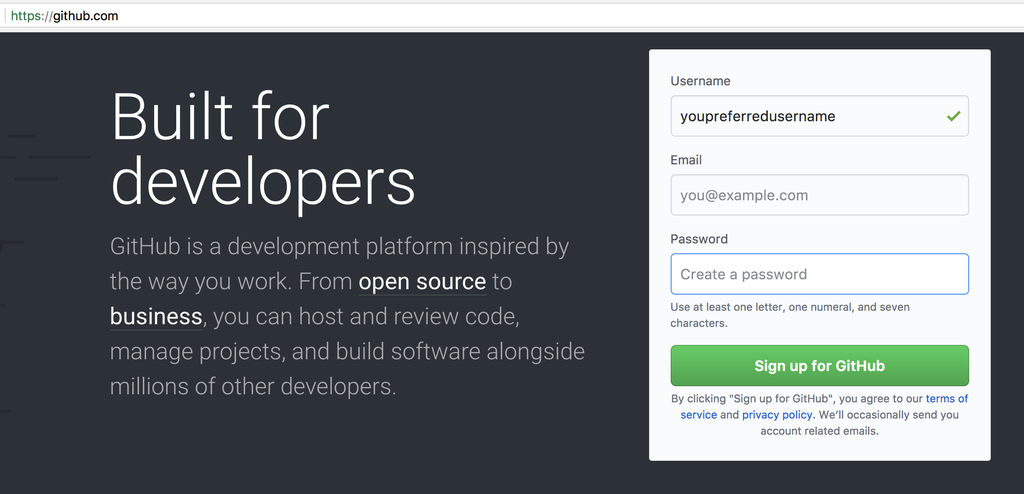

## Создание репозитория

Кликнув на “плюсик” `+` в верхнем правом углу любой страницы GitHub, создайте новый репозиторий (место, где будут храниться материалы для одного проекта).

[figure not shown]

Добавьте описание проекта. Если вы планируете использовать GitHub только из браузера, в настройках укажите `Initialize this repository with a README`.

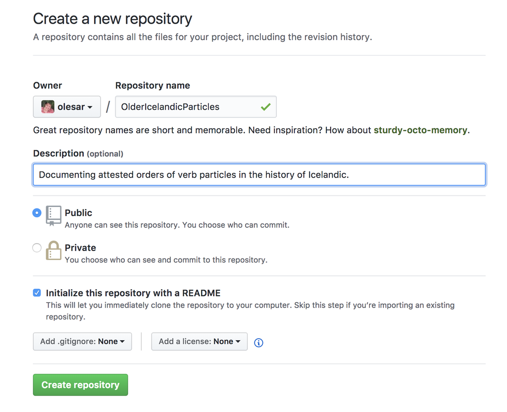

**Примечание**. Вы можете пропустить этот шаг, если планируйте пользоваться только репозиториями, созданными другими пользователями. Если вы опытный пользователь и планируете синхронизировать свою версию репозитория на локальном компьютере с онлайн-версией, лучше не создавать readme файл.

## Структура репозитория

Репозиторий - это, по сути, то же самое, что папка с файлами на вашем компьютере. Файлы могут храниться как в основной части (корне репозитория), так и во вложенных папках. Вот так выглядит пример [репозитория](https://github.com/ruRust/rust_book_ru):

[figure not shown]

Хорошим тоном считается хранить описание каждой папки и путеводитель по полезной для пользователей информации в файле readme. По умолчанию, файл readme.md или readme.txt воспроизводится в браузере под списком файлов.

Вы можете войти на страницу файла или вложенной папке, кликнув по ним. Вернуться обратно вы можете, кликнув на название репозитория или верхней папки в строке навигации.

[figure not shown]

## Редактирование файла

На странице файла (то есть, когда вы кликнули по файлу и перешли на его страницу) справа есть значок “карандаша”.

[figure not shown]

По клику на этом значке откроется окно для редактирования. Этим окном можно пользоваться как простым текстовым редактором.

[figure not shown]

**Не забудьте сохранить изменения – commit!**  
После того, как вы записали что-то в файл или отредактировали содержимое, промотайте страницу вниз. Напишите кратко, какие изменения вы внесли, и нажмите кнопку `Commit`.

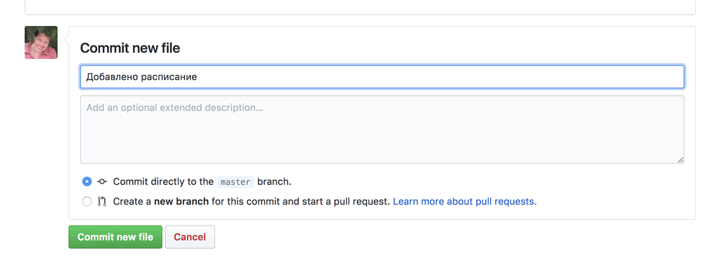

## Редактирование файла md (markdown documents)

Маркдаун (markup document format) - простой формат для представления заголовков разных уровней, выделения жирным или курсивом, создания списков, таблиц, гиперссылок и так далее. GitHub автоматически конвертирует текст с маркдауном так, чтобы он красиво отражался в браузере. Полезные короткие инструкции хранятся [тут](https://github.com/adam-p/markdown-here/wiki/Markdown-Cheatsheet), [тут](http://www.rstudio.com/wp-content/uploads/2016/03/rmarkdown-cheatsheet-2.0.pdf) и [тут](https://guides.github.com/pdfs/markdown-cheatsheet-online.pdf).

Вот пример md-файла:

```
## Введение

Краткое содержание:

* Как искать слово
* Как искать сочетание существительного с числительным *два*
* Пример поиска на [Яндексе](https://ya.ru/)
```

Над окном редактирование находится вкладка **Preview changes**, кликнув на которую можно увидеть, как будет выглядеть файл в браузере.

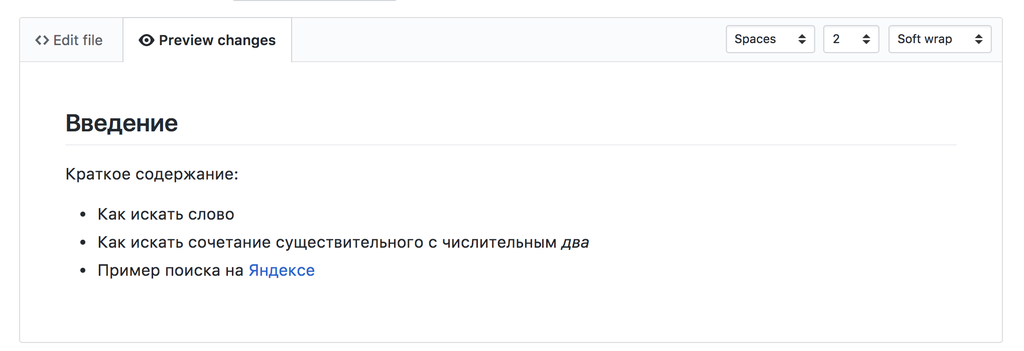

В конце не забудьте нажать Commit.

## Добавление и удаление файлов

- Загрузить файл в папку – Находясь в корне репозитория или во вложенной папке, нажать `Upload files`.
- Создать новый файл  
  – … нажать `Create new file`, задать имя файла, отредактировать и сделать Commit.
- Создать новую папку  
  – … нажать `Create new file`, задать путь к файлу и имя файла так: `dict/readme.me` (к сожалению, в браузере нельзя создать пустую папку, но вообще-то хорошо иметь в ней readme файл).
- Удалить файл  
  – находясь на странице файла, кликнуть на иконку “Корзина” (справа от “карандаша”).
- Удалить папку  
  – удалить все файлы в папке. Папка удалится автоматически.